# IST 718: Big Data Analytics

- Professor: Daniel Acuna deacuna@syr.edu

## General instructions:

- You are welcome to discuss the problems with your classmates but **you are not allowed to copy any part of your answers either from your classmates or from the internet**
- You can put the homework files anywhere you want in your http://notebook.acuna.io workspace but *do not change* the file names. The TAs and the professor use these names to grade your homework.
- Remove or comment out code that contains `raise NotImplementedError`. This is mainly to make the `assert` statement fail if nothing is submitted.
- The tests shown in some cells (i.e., `assert` and `np.testing.` statements) are used to grade your answers. **However, the professor and TAs will use **additional** test for your answer. Think about cases where your code should run even if it passess all the tests you see.**
- Before downloading and submitting your work through Blackboard, remember to save and press `Validate` (or go to `Kernel`$\rightarrow$`Restart and Run All`).
- Good luck!

# Part 1

**Note: for the following questions, do them either as Latex inside markdown or on paper and take a picture, copy and paste it inside markdown. Show your work.**

Assume that data is being generated from a distribution and that your estimator $\hat{f}(X)$ varies as follows. Assume further that there is no noise or irreducible noise (i.e., $E[\epsilon^2] = 0$)

| x | $\hat{f}$ | p(x, $\hat{f}$) |
| --- | --- | --- |
| 0 | 0 | 0.4 |
| 0 | 1 | 0.2 |
| 1 | 0 | 0.1 |
| 1 | 1 | 0.3 |

We measure the performance of our classifier with the squared error $(\hat{Y}-Y)^2$. Assume that the true function is as follows

$$ Y=f(X=x)=\begin{cases} 0 & x=0\\ 1 & x=1 \end{cases} $$

# Question 1

**(5 pts)** Estimate the expected value $E[\hat{f}(X=0) | X=0]$

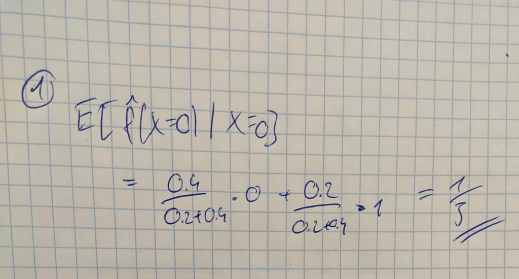

# Question 2

**(5 pts)** Estimate the expected value $E[\hat{f}(X=1) | X=1]$

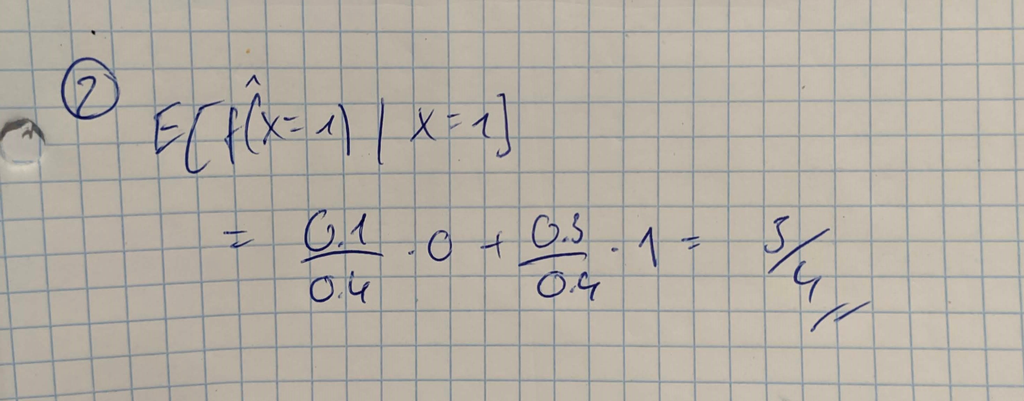

# Question 3

**(10 pts)** Using one of the terms of the bias-variance tradeoff equation, estimate the bias-squared of the estimation $\hat{f}(X)$ when $X=0$

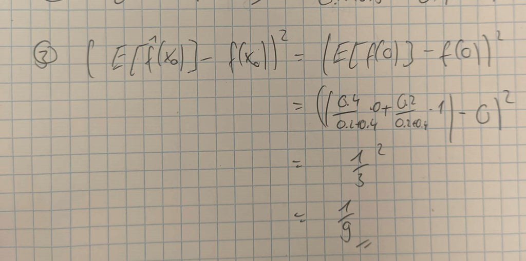

# Question 4

**(10 pts)** Using one of the terms of the bias-variance tradeoff equation, estimate the variance of the estimation $\hat{f}(X)$ when $X=0$

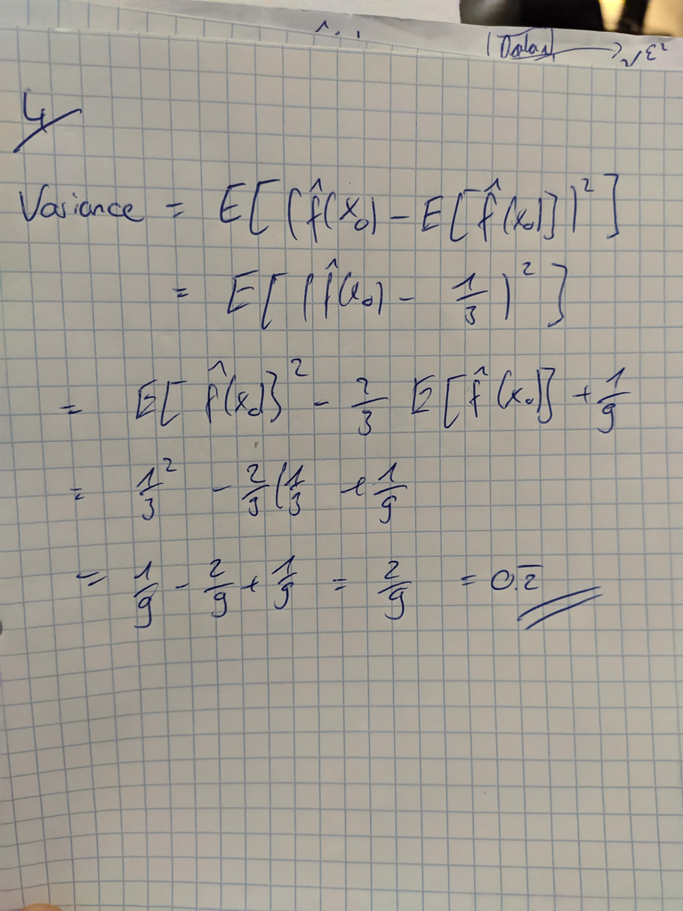

# Question 5

**(10 pts)** For the same data-generating process, imagine that another estimation $\hat{g}(X)$ has the following distribution

| x | $\hat{g}$ | p(x, $\hat{g}$) |
| --- | --- | --- |
| 0 | 0 | 1/4 |
| 0 | 1 | 1/4 |
| 1 | 0 | 1/4 |
| 1 | 1 | 1/4 |

Estimate the mean squared error of $\hat{f}$ and $\hat{g}$ at $X=1$. If the MSE of $\hat{g}$ is bigger (or smaller) than that of $\hat{f}$, which is the biggest contributor to the change in $\hat{g}$, bias or variance?

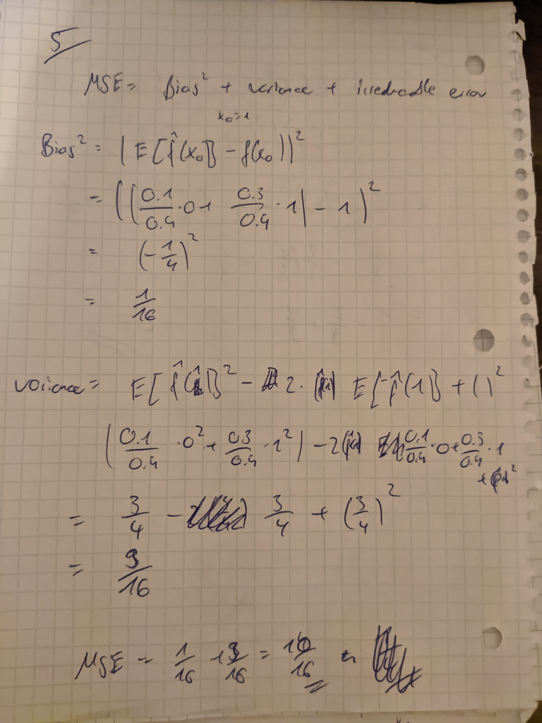

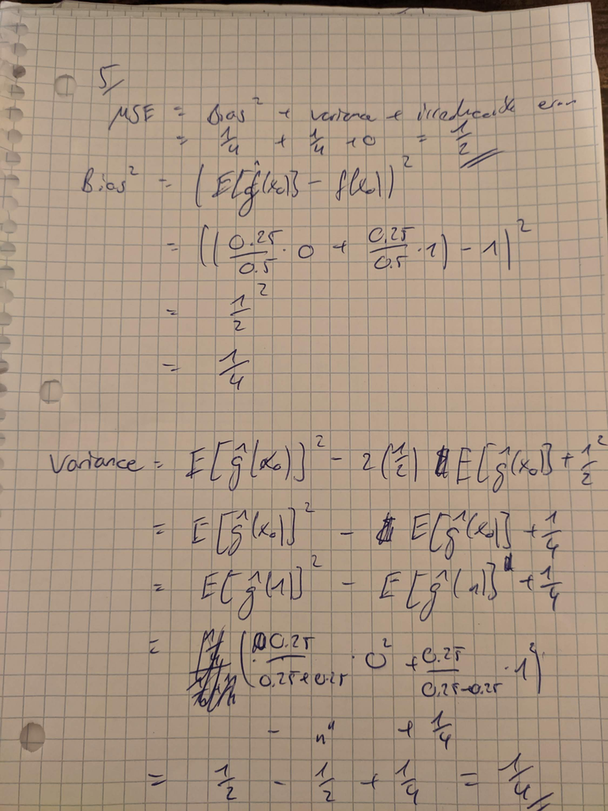

MSE of $\hat{f}$ at $X=1$ is 10/16 - bias^2 contributes less than variance to MSE

MSE of $\hat{g}$ at $X=1$ is 1/2 - bias^2 and variance contribute equally to MSE

MSE of $\hat{g}$ at $X=1$ is smaller than MSE of $\hat{f}$ at $X=1$